# Trends in Antibiotic Prescription in Scotland in 2021 - is there correlation with COVID-19 cases?

Annie Brady

2024-11-24

```r
library(tidyverse)
library(janitor) # cleaning data
library(here) # for help importing data
library(knitr) #for making tables
library(kableExtra) #for improving my tables
library(sf) #for making the map plot
```

### Introduction.

Antimicrobial resistance (AMR) is a growing global concern, and one of the key contributors to its rise is the overuse and misuse of antibiotics (Shallcross & Davies, 2014). In this context, it is crucial to understand how patterns of antibiotic prescriptions may be influenced by factors such as the COVID-19 pandemic. Specifically, I aimed to investigate whether the prescription rates of these antibiotics rose and fell with the number of COVID-19 cases, potentially indicating the prescription of antibiotics to people suffering from COVID, not bacterial infections. It is important to note that COVID-19 is caused by a virus, and antibiotics are not effective in treating viral infections. Therefore, any rise in prescriptions could reflect inappropriate use of antibiotics, which may contribute to the AMR problem.

In this report, I explored the relationship between the prescription of nine antibiotics commonly prescribed to treat respiratory infections, and the number of COVID-19 cases in Scotland in 2021.I went on to consider whether the increase in antibiotic use was due to secondary bacterial pneumonia in COVID cases, by comparing trends in antibiotic prescriptions with trends in hospital admissions for COVID-19. Following this, I visualised Antibiotic Prescriptions per Capita for each health board to investigate differing prescription rates in each Health Board.

### Prescriptions Data.

```r
function_clean_filter_drugs <- function(data_month) {
    read_csv(here("data", data_month), show_col_types = FALSE) %>%
    clean_names() %>% #Using the 'clean_names' function to clean up the column names by adding underscores and making them all lowercase.
    filter(str_detect(bnf_item_description, c("PHENOXYMETHYLPENICILLIN|AMOXICILLIN| CO_AMOXICLAV|AZITHROMYCIN|CLARITHROMYCIN|ERYTHROMYCIN|VIBRAMYCIN|DOXYCYCLINE|CEFALEXIN"))) %>% #I then use the 'str_detect' command to filter for any rows containing the above drug names in the column "bnf_item_description".
    filter(paid_quantity == floor(paid_quantity))  #floor rounds down to the nearest whole number, so this line filters for values in 'paid_quantity' that have no decimals.
  }
```

Then I downloaded the data sets for each month in 2021, so that I could plot a graph of the correlation between antibiotic prescriptions and COVID cases in 2021. I did this by creating a vector containing the file names. Then I used the `map()` function to apply `function_clean_filter_drugs` to each month. I renamned the files in the vector with the month they correspond to for ease of analysis later on.

```r
prescription_files <- c("pitc202101.csv", "pitc202102.csv", "pitc202103.csv", "pitc202104.csv",
  "pitc202105.csv", "pitc202106.csv", "pitc202107.csv",
  "pitc202108.csv", "pitc202109.csv", "pitc202110.csv",
  "pitc202111.csv", "pitc202112.csv") #creating a vector containing the files
prescription_data_list <- map(prescription_files, function_clean_filter_drugs) #map() applies function_clean_filter_drugs to all of the files in prescription_files
names(prescription_data_list) <- c("January", "February", "March", "April", "May", "June", "July", "August", "September", "October", "November", "December") #renaming the items
```

Then I wrangled these to give totals for each health board. I chose to calculate total in each health board, firstly so I could easily join the data sets, but also so that later on I could compare the rates of antibiotic prescription in each health board, and see if there are any that have especially high rates of prescription.

```r
function_summarise_prescriptions <- function(data, month_name) {
  data %>%
    group_by(hbt) %>%
    summarise(!!month_name := sum(paid_quantity)) %>% #create a new column, named based of month_name
    filter(hbt != "SB0806") #removing an error - this health board does not exist
}
#imap() maps over the elements in prescription_data_list, applying the function_summarise_prescriptions and give the new value and its name.
summarised_prescriptions <- imap(prescription_data_list, function_summarise_prescriptions)
```

Then I joined the totals from each month together, and wrangled the data using `pivot_longer` to create a dataset containing prescriptions per month for 2021. I then visualised this data frame in a table using `kable()`.

```r
prescriptions_2021 <- reduce(summarised_prescriptions, full_join, by = "hbt") #reduce combines all the elements in the list into one result, through a full_join by hbt
prescriptions_monthly_totals <- prescriptions_2021 %>%
  select(-hbt) %>%
  pivot_longer(cols = c("January":"December"), #create a 'month' column and a 'prescriptions' column
               names_to = "month",
               values_to = "prescriptions") %>%
  group_by(month) %>%
  summarise(prescriptions = sum(prescriptions)) %>% #the months are lowercase and out of order, so this needs fixing.
  mutate(month = factor(month, levels = month.name, ordered = TRUE)) %>% #this coverts the month column to factors with specified levels. month.name is a built in character vector that contains the names of the months in order.
  arrange(month) #arrange the months in order

prescriptions_monthly_totals %>%
  kable(col.names = c("Month", "Antibiotic Prescriptions"),
        align = "lc", #align data in rows, to the left, in the centre.
        caption = "Antibiotic Prescriptions per Month in Scotland, 2021") %>%
  kable_styling("striped", full_width = FALSE)
```

Antibiotic Prescriptions per Month in Scotland, 2021

| Month | Antibiotic Prescriptions |
| --- | --- |
| January | 4033512 |
| February | 3631401 |
| March | 4406851 |
| April | 4252437 |
| May | 4724842 |
| June | 5267509 |
| July | 4639049 |
| August | 4967232 |
| September | 7394363 |
| October | 7400721 |
| November | 8323910 |
| December | 8313228 |

### COVID Data

Next, I accessed COVID data from Public Health Scotland - this data set is “Weekly Tests and Cases by Health Board”. I chose this set so that I could join it to my other data by health board.

```r
covid_cases_tests_hb <- read_csv(here("data", "weekly_tests_cases_hb_20241113.csv"), show_col_types = FALSE) %>%
  clean_names() %>%
  filter(hb != "S92000003") %>% #removed the aggregated data for the whole of Scotland
  mutate(week_ending = ymd(week_ending)) #convert the week_ending column from dbl to date for easier analysis.
```

I then filtered for the year 2021, so that I could compare it to my prescriptions data. I wrangled the data so that it could be joined to `prescriptions_2021`.

```r
covid_monthly_total_2021 <- covid_cases_tests_hb %>%
  filter(year(week_ending) == 2021) %>% #filter for only the year 2021
  mutate(month = month(week_ending)) %>% #create a column containing the month so that group_by can be applied
  group_by(month) %>%
  summarise(monthly_cases = sum(weekly_cases)) %>% #add up the weekly cases, presenting total per month.
    mutate(month = recode(month, "1" = "January","2" = "February","3" = "March","4" = "April","5" = "May","6" = "June","7" = "July","8" = "August", "9" = "September","10" = "October","11" = "November","12" = "December")) #mutate to change the numbered month to the month name, so that it can be joined to the prescriptions data.

prescriptions_covid_2021 <- prescriptions_monthly_totals %>%
  full_join(covid_monthly_total_2021, by = "month") #full_join used to keep all the data from both dataframes
```

### Comparison

In order to see correlation between COVID cases and prescriptions, the data must be visualized on a graph. Here I used `geom_point` and `geom_smooth` from `ggplot()` to generate a graph with prescriptions on the x-axis, and COVID cases on the y-axis, with a line representing the correlation between the two variables.

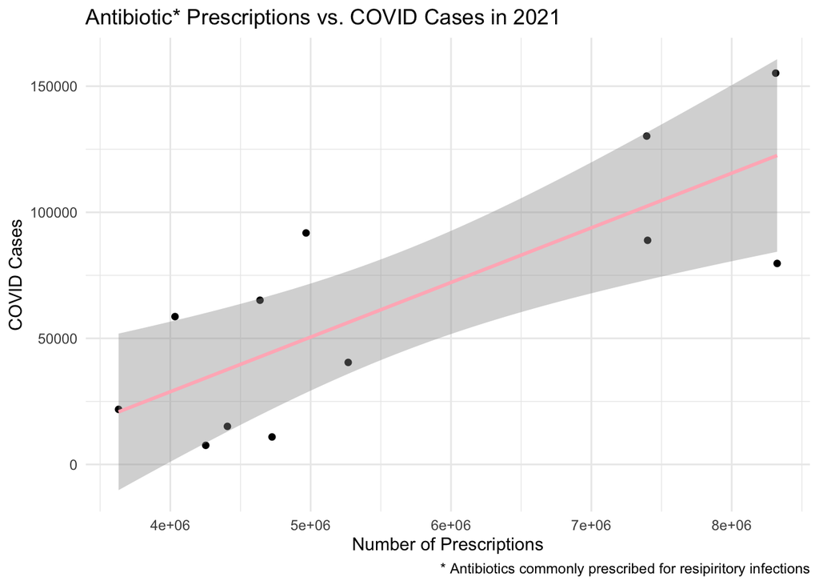

```r
prescriptions_covid_2021 %>%
  ggplot(aes(x = prescriptions,
             y = monthly_cases)) +
  geom_point()+
  geom_smooth(method = "lm", color = "lightpink", linetype = "solid", size = 1) + #method = lm instructs geom_smooth to use a linear regression model to make a line that represents the relationship between x and y.
  labs(title = "Antibiotic* Prescriptions vs. COVID Cases in 2021", x = "Number of Prescriptions", y = "COVID Cases",
       caption = "* Antibiotics commonly prescribed for resipiritory infections") +
  theme_minimal()
```

This graph shows a positive correlation between the number of antibiotic prescriptions and COVID cases. The grey area represents the 95% confidence interval for the fitted line. This correlation confirms the possibility that antibiotics may have been wrongly prescribed to treat COVID in 2021.  
Another theory to explain the correlation between antibiotic prescription and COVID cases is that some people may developed bacterial pneumonia after COVID, and would therefore be prescribed antibiotics. To investigate this, I accessed COVID hospital admissions data, titled ‘Weekly Admissions by Age’. I decided to use hospital admissions data, as only severe COVID infections are admitted to hospital, and these cases are more likely to go on to develop bacterial pneumonia (Wu, Adhi & Highland, 2020). I filtered for the year 2021 and summarized to calculate total admissions per month. I then joined this to `prescriptions_monthly_totals` in order to visualize the trends in admissions and prescriptions on the same graph. I divided the prescriptions values by 1000 so that both variables could be plotted on the same set of axis.

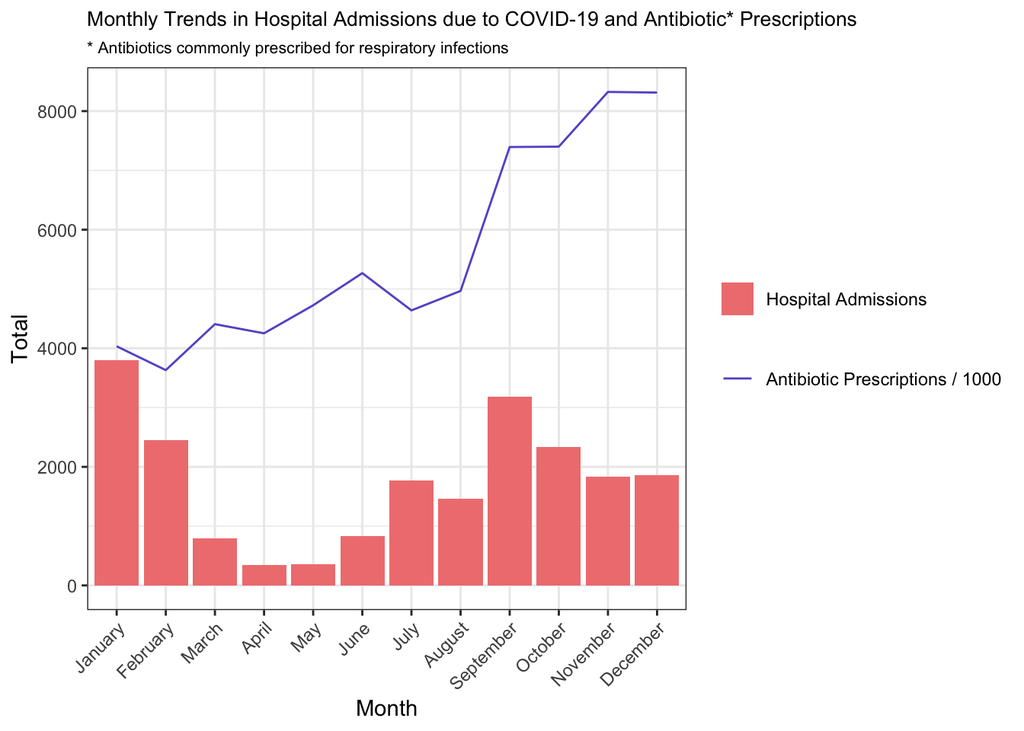

```r
covid_admissions <- read_csv(here("data", "admissions_ageband_week_20231004.csv"), show_col_types = FALSE) %>%
  clean_names() %>%
  filter(str_detect(date, "2021")) %>% #filter for the year 2021
  mutate(date = ymd(date), #change the date column from 'character' to 'date'
         month = month(date)) %>% #create a column containing month
  group_by(month) %>%
  summarise(monthly_admissions = sum(number_admitted)) %>% #calculate total admissions per month
  mutate(month = recode(month, "1" = "January","2" = "February","3" = "March","4" = "April","5" = "May","6" = "June","7" = "July","8" = "August", "9" = "September","10" = "October","11" = "November","12" = "December")) #rename the numeric months the month names

admissions_prescriptions <- covid_admissions %>%
  full_join(prescriptions_monthly_totals, by = "month") %>%
  mutate(month = factor(month, levels = month.name, ordered = TRUE), #puts months in correct order
         prescriptions_1000 = prescriptions/1000) #divide by 1000 so that prescription and admissions can be plotted on the same axis
admissions_prescriptions %>%
  ggplot(aes(x = month)) +
  geom_col(aes(y = monthly_admissions, fill = "Hospital Admissions")) +
  geom_line(aes(y = prescriptions_1000, colour = "Antibiotic Prescriptions / 1000"), group = 1) +
  scale_fill_manual(values = c("Hospital Admissions" = "lightcoral")) +  #Define color for fill legend
  scale_colour_manual(values = c("Antibiotic Prescriptions / 1000" = "slateblue3"))+ # Define color for fill legend
  labs(x = "Month",
       y = "Total",
       title = "Monthly Trends in Hospital Admissions due to COVID-19 and Antibiotic* Prescriptions",
       subtitle = "* Antibiotics commonly prescribed for respiratory infections",
       colour = NULL,
       fill = NULL) + #remove legend titles 'fill' and 'colour'
  theme_bw() +
  theme(axis.text.x = element_text(angle = 45, hjust = 1), #tilt acis titles for readability
        plot.title = element_text(size = 10), #decrease plot title size so it fits on page
        plot.subtitle = element_text(size = 8))
```

This graph shows that there is not a clear correlation between the trends in Admissions and Prescriptions in 2021. However, in order to rule out COVID related bacterial pneumonia as the cause of increased antibiotic use, details on reasons for prescription would be required, which is beyond the scope of this report.

It would be interesting to see whether there were some health boards in Scotland that were prescribing these antibiotics at a higher rate than others. It may then be possible to target doctors in these health boards with information campaigns about the dangers of over-prescribing antibiotics and how it may cause AMR.  
It would be helpful to visualize the rates of antibiotic prescription per capita in each health board on a map. To do this I accessed the data set with Health Board Names and joined it to my prescriptions data. I also required data on the population size of each Health Board in 2021, which I got from the data set ‘Health Board Projections’ and filtered for the year 2021.

```r
hb_names <- read_csv(here("data", "hb14_hb19.csv"), show_col_types = FALSE) %>%
  clean_names() %>%
  select(hb, hb_name) #these are the only columns needed for this analysis.

prescriptions_hb_name <- prescriptions_2021 %>%
  left_join(hb_names, by = c("hbt" = "hb")) %>%
  group_by(hb_name) %>%
  summarise(total_prescriptions = sum(across(January:December))) #'across' to select the columns from january to december to apply the 'sum' to.
population_hb <- read_csv(here("data", "hb_pop_proj_03072020.csv"), show_col_types = FALSE) %>%
  clean_names() %>%
  filter(year == "2021", #filter for only  the year 2021
         sex == "All", #removing the Female and Male rows, as I'm not looking at gender differences.
         hb != "S92000003") #removing the aggregated data for Scotland as a whole, as I only have prescription data separated by health board
prescriptions_hb_rates <- population_hb %>%
  left_join(hb_names, by = "hb") %>% #only need the hb_names for the hb's included in my data
  full_join(prescriptions_hb_name, by = "hb_name") %>%
  group_by(hb_name) %>%
  mutate(prescription_rate = (total_prescriptions / all_ages)) #divide the total number of prescriptions by the population of that health board, so get Prescription per Captia, so I can compare between health boards of different sizes
```

After I had joined the three data sets, and calculated Prescription per Capita, I wanted to visualize this on a map.  
To do this, I needed spatial data on the health boards. I joined this spatial data set to `prescriptions_hb_rates`. I used this joined dataset to create a map of Scottish Health Boards, with colour varying by prescriptions per captia.

```r
nhs_healthboards <- st_read(here("data", "NHS_healthboards_2019.shp")) %>%
  clean_names()
```

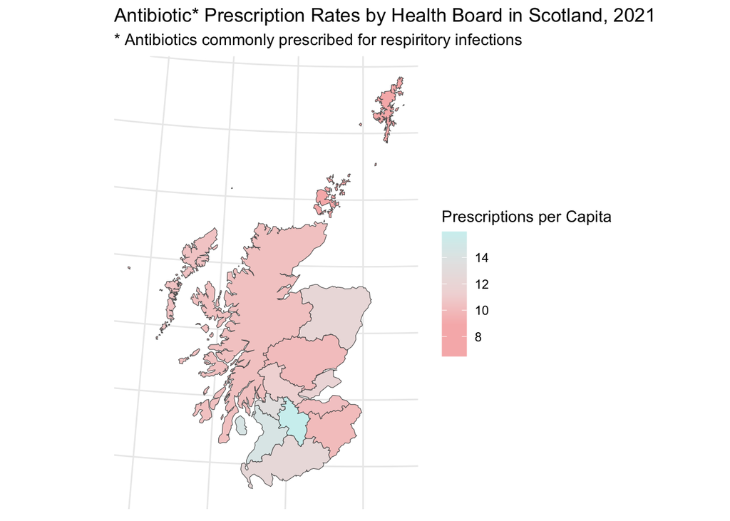

```r
rates_nhs_healthboards <- prescriptions_hb_rates %>%
  mutate(hb_name = str_remove(hb_name, "NHS ")) %>% #remove 'NHS' from the HB Names, as `nhs_healthboards` does not have this prefix, so that they can be joined by `hb_name`.
  full_join(nhs_healthboards, join_by(hb_name)) %>%
  st_as_sf() #transforms this object to sf, so that it can be used with geom_sf to plot a map.

rates_nhs_healthboards %>%
  ggplot() +
  geom_sf(aes(fill = prescription_rate)) +  # Use fill for the rate
  scale_fill_gradientn(colors = c("#f7b7b7", "#f7b7b7", "#f1d9d9", "#e5e5e5", "#d0f0f0"))+#color scale for prescriptions per captia.
  labs(fill = "Prescriptions per Capita",  # Legend title
       title = "Antibiotic* Prescription Rates by Health Board in Scotland, 2021",
       subtitle = "* Antibiotics commonly prescribed for respiritory infections") +
  theme_minimal() +
  theme(axis.text = element_blank(),
        axis.ticks = element_blank()) # Hide axis text and ticks, as they are not needed.
```

This map shows that the Lanarkshire has notably higher antibiotic prescriptions rates than other health boards in Scotland. More investigation is required to determine the cause of this. Some have suggested that the increase in telephone appointments with GPs due to lock-down restrictions limiting face-to-face appointments is to blame for the rise in antibiotic use (Gagliotti, *et al*. 2021). Further research could compare rates of telephone consultation in each health board to antibiotic prescription rates to ascertain whether this is true. Similarly, there may be unique population dynamics, access issues or other factors such as level of deprivation that are influencing prescription rates. Further study should examine the factors causing higher prescription rates, so that policy changes can work to reduce and eliminate unnecessary antibiotic prescription.

### File Storage

Files were downloaded from [Public Health Scotland](https://www.opendata.nhs.scot/) and stored in a folder titled ‘data’. They were accessed using `here()`.  
The following datasets were used: [Prescriptions in the Community - by Prescriber Location Jan-Dc 2021](https://www.opendata.nhs.scot/dataset/prescriptions-in-the-community), [Weekly Tests and Cases by Health Board](https://www.opendata.nhs.scot/dataset/viral-respiratory-diseases-including-influenza-and-covid-19-data-in-scotland/resource/2803acc8-8ec3-4c4a-81a5-f10952bf66f4), [Health Board 2014 - Health Board 2019](https://www.opendata.nhs.scot/dataset/geography-codes-and-labels/resource/652ff726-e676-4a20-abda-435b98dd7bdc), [Health Board Projections](https://www.opendata.nhs.scot/dataset/population-projections/resource/0876fc67-05e6-4e87-bc30-c4b0756fff04), [Weekly Admissions by Age](https://www.opendata.nhs.scot/dataset/covid-19-in-scotland/resource/b5e3fa11-8a85-4946-bbb2-2e800d4e3594), [NHS Health Boards Scotland - Spatial Data .zip file](https://spatialdata.gov.scot/geonetwork/srv/api/records/f12c3826-4b4b-40e6-bf4f-77b9ed01dc14).

### Generative AI Statement

Generative AI was used in this report to trouble-shoot. Error messages were pasted into ChatGPT to identify mistakes in the code, for example missing quotation marks (““) or commas (,). It was not used to write code.

### References

Gagliotti, C., Buttazzi, R., Ricchizzi, E., Di Mario, S., Tedeschi, S. and Moro, M.L. (2021). Community use of antibiotics during the COVID-19 lockdown. Infectious Diseases, 53(2), pp.142-144.

NHS (2022) Antibiotics - Overview. Available at: https://www.nhs.uk/conditions/antibiotics/ (Accessed: 18 November 2024).

Shallcross, L.J. and Davies, D.S.C. (2014). Antibiotic overuse: a key driver of antimicrobial resistance. British Journal of General Practice, 64(629), pp.604-605.

Wu, C.P., Adhi, F. and Highland, K. (2020). Recognition and management of respiratory co-infection and secondary bacterial pneumonia in patients with COVID-19. Cleveland Clinic journal of medicine, 87(11), pp.659-663.